# Gene Panel Analysis Report

Stephen Kelly

March 17, 2017

# 1 Analysis Information

Analysis ID:

**ExampleIonTorrentRun123**

Run ID:

**ExampleRunID**

Samples included in the analysis.

|  | Sample.Name | Barcode |
| --- | --- | --- |
| 1 | SC | IonXpress_001 |
| 2 | Sample2 | IonXpress_002 |
| 3 | Sample3 | IonXpress_003 |
| 4 | Sample4 | IonXpress_004 |
| 5 | Sample5 | IonXpress_005 |
| 6 | Sample1 | IonXpress_006 |
| 7 | Sample6 | IonXpress_007 |
| 8 | NC | IonXpress_008 |

# 2 Variant Table

## 2.1 Non-SC Samples

The following variants are detected:

|  | Gene | Coding | Amino.Acid.Change | Frequency | Review | Sample.Name | Barcode |
| --- | --- | --- | --- | --- | --- | --- | --- |
| 1 | PIK3CA | c.A3140G | p.H1047R | 0.176 | US | Sample2 | IonXpress_002 |
| 2 | KRAS | c.G34T | p.G12C | 0.342 | KS | Sample2 | IonXpress_002 |
| 3 | TP53 | c.G1015T | p.E339X | 0.165 | US | Sample2 | IonXpress_002 |
| 4 | TP53 | c.C742T | p.R248W | 0.560 | US | Sample1 | IonXpress_006 |
| 5 | BRAF | c.T1799A | p.V600E | 0.168 | KS | Sample4 | IonXpress_004 |
| 6 | APC | c.3932dupT | p.I1311fs | 0.151 | US | Sample5 | IonXpress_005 |
| 7 | JAK3 | c.G2164A | p.V722I | 0.556 | US | Sample5 | IonXpress_005 |
| 8 | CTNNB1 | c.T97C | p.S33P | 0.214 | US | Sample3 | IonXpress_003 |
| 9 | PTEN | c.A43T | p.R15X | 0.340 | US | Sample6 | IonXpress_007 |
| 10 | TP53 | c.C586T | p.R196X | 0.303 | US | Sample6 | IonXpress_007 |

## 2.2 SC Sample

The following variants were detected in the SC control sample:

|  | Gene | Coding | Amino.Acid.Change | Frequency | Review | Sample.Name | Barcode |
| --- | --- | --- | --- | --- | --- | --- | --- |
| 1 | MPL | c.G1514A | p.S505N | 0.108 | US | SC | IonXpress_001 |
| 2 | MPL | c.G1544T | p.W515L | 0.104 | US | SC | IonXpress_001 |
| 3 | MPL | c.G1555A | p.A519T | 0.099 | US | SC | IonXpress_001 |
| 4 | NRAS | c.A182G | p.Q61R | 0.062 | KS | SC | IonXpress_001 |
| 5 | NRAS | c.G52A | p.A18T | 0.082 | KS | SC | IonXpress_001 |
| 6 | NRAS | c.G35A | p.G12D | 0.078 | KS | SC | IonXpress_001 |
| 7 | NRAS | c.G29A | p.G10E | 0.076 | KS | SC | IonXpress_001 |
| 8 | ALK | c.G3824A | p.R1275Q | 0.104 | US | SC | IonXpress_001 |
| 9 | ALK | c.C3522A | p.F1174L | 0.090 | US | SC | IonXpress_001 |
| 10 | IDH1 | c.G395A | p.R132H | 0.087 | KS | SC | IonXpress_001 |
| 11 | IDH1 | c.A388G | p.I130V | 0.085 | KS | SC | IonXpress_001 |
| 12 | IDH1 | c.G367A | p.G123R | 0.089 | KS | SC | IonXpress_001 |
| 13 | ERBB4 | c.G2791T | p.D931Y | 0.092 | US | SC | IonXpress_001 |
| 14 | ERBB4 | c.G2782T | p.E928X | 0.092 | US | SC | IonXpress_001 |
| 15 | ERBB4 | c.G1835A | p.R612Q | 0.090 | US | SC | IonXpress_001 |
| 16 | ERBB4 | c.C1828A | p.P610T | 0.088 | US | SC | IonXpress_001 |
| 17 | ERBB4 | c.A1784G | p.D595G | 0.096 | US | SC | IonXpress_001 |
| 18 | ERBB4 | c.C1022T | p.S341L | 0.094 | US | SC | IonXpress_001 |
| 19 | ERBB4 | c.G1003T | p.D335Y | 0.102 | US | SC | IonXpress_001 |
| 20 | ERBB4 | c.T885G | p.H295Q | 0.101 | US | SC | IonXpress_001 |
| 21 | ERBB4 | c.C829A | p.H277N | 0.099 | US | SC | IonXpress_001 |
| 22 | ERBB4 | c.C804A | p.Y268X | 0.097 | US | SC | IonXpress_001 |
| 23 | ERBB4 | c.A730G | p.T244A | 0.099 | US | SC | IonXpress_001 |
| 24 | ERBB4 | c.C704T | p.A235V | 0.099 | US | SC | IonXpress_001 |
| 25 | ERBB4 | c.A542G | p.N181S | 0.097 | US | SC | IonXpress_001 |
| 26 | ERBB4 | c.C515G | p.P172R | 0.092 | US | SC | IonXpress_001 |
| 27 | VHL | c.T266A | p.L89H | 0.082 | US | SC | IonXpress_001 |
| 28 | VHL | c.G277C | p.G93R | 0.081 | US | SC | IonXpress_001 |
| 29 | VHL | c.C286T | p.Q96X | 0.080 | US | SC | IonXpress_001 |
| 30 | VHL | c.C343A | p.H115N | 0.093 | US | SC | IonXpress_001 |

[output cut: 309 more lines]

# 3 IGV Snapshots

## 3.1 KRAS c.G34T IonXpress_002

Variant ID:

`ExampleIonTorrentRun123.IonXpress_002.KRAS.chr12.25398285.c.G34T`

| Gene | Coding | Amino.Acid.Change | Frequency | Review | Sample.Name | Barcode |
| --- | --- | --- | --- | --- | --- | --- |
| KRAS | c.G34T | p.G12C | 0.342 | KS | Sample2 | IonXpress_002 |

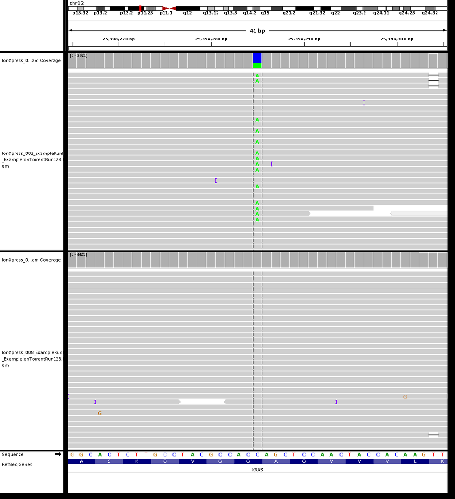

## 3.2 PIK3CA c.A3140G IonXpress_002

### 3.2.1 Short View

Variant ID:

`ExampleIonTorrentRun123.IonXpress_002.PIK3CA.chr3.178952085.c.A3140G`

| Gene | Coding | Amino.Acid.Change | Frequency | Review | Sample.Name | Barcode |
| --- | --- | --- | --- | --- | --- | --- |
| PIK3CA | c.A3140G | p.H1047R | 0.176 | US | Sample2 | IonXpress_002 |

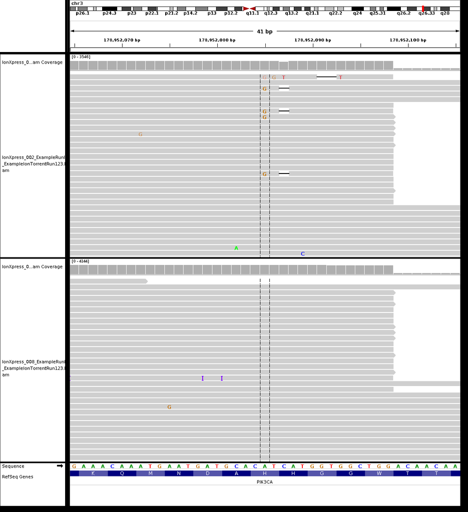

### 3.2.2 Long View

Variant ID:

`ExampleIonTorrentRun123.IonXpress_002.PIK3CA.chr3.178952085.c.A3140G`

| Gene | Coding | Amino.Acid.Change | Frequency | Review | Sample.Name | Barcode |
| --- | --- | --- | --- | --- | --- | --- |
| PIK3CA | c.A3140G | p.H1047R | 0.176 | US | Sample2 | IonXpress_002 |

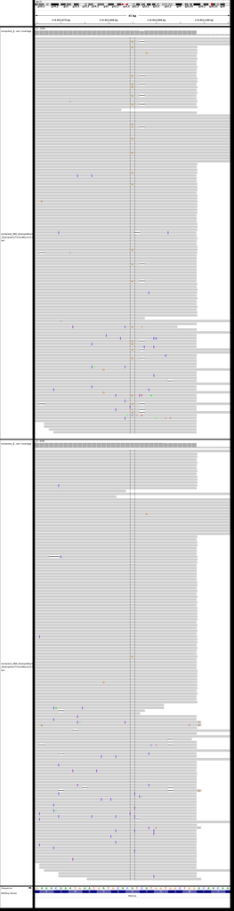

## 3.3 TP53 c.G1015T IonXpress_002

### 3.3.1 Short View

Variant ID:

`ExampleIonTorrentRun123.IonXpress_002.TP53.chr17.7574012.c.G1015T`

| Gene | Coding | Amino.Acid.Change | Frequency | Review | Sample.Name | Barcode |
| --- | --- | --- | --- | --- | --- | --- |
| TP53 | c.G1015T | p.E339X | 0.165 | US | Sample2 | IonXpress_002 |

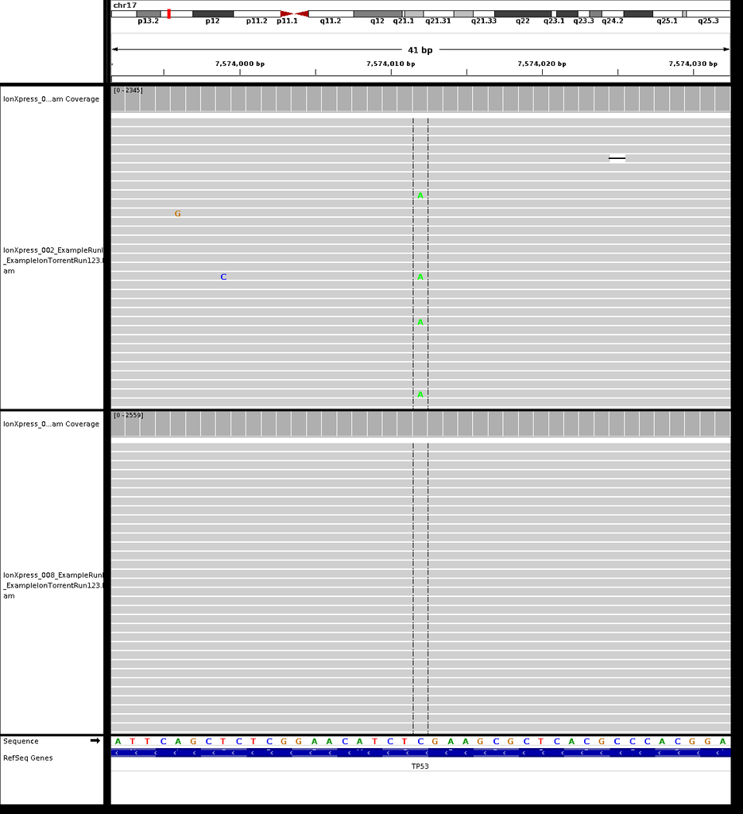

### 3.3.2 Long View

Variant ID:

`ExampleIonTorrentRun123.IonXpress_002.TP53.chr17.7574012.c.G1015T`

| Gene | Coding | Amino.Acid.Change | Frequency | Review | Sample.Name | Barcode |
| --- | --- | --- | --- | --- | --- | --- |
| TP53 | c.G1015T | p.E339X | 0.165 | US | Sample2 | IonXpress_002 |

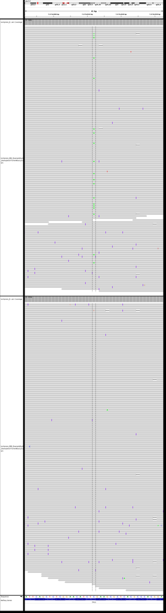

## 3.4 CTNNB1 c.T97C IonXpress_003

### 3.4.1 Short View

Variant ID:

`ExampleIonTorrentRun123.IonXpress_003.CTNNB1.chr3.41266100.c.T97C`

| Gene | Coding | Amino.Acid.Change | Frequency | Review | Sample.Name | Barcode |
| --- | --- | --- | --- | --- | --- | --- |
| CTNNB1 | c.T97C | p.S33P | 0.214 | US | Sample3 | IonXpress_003 |

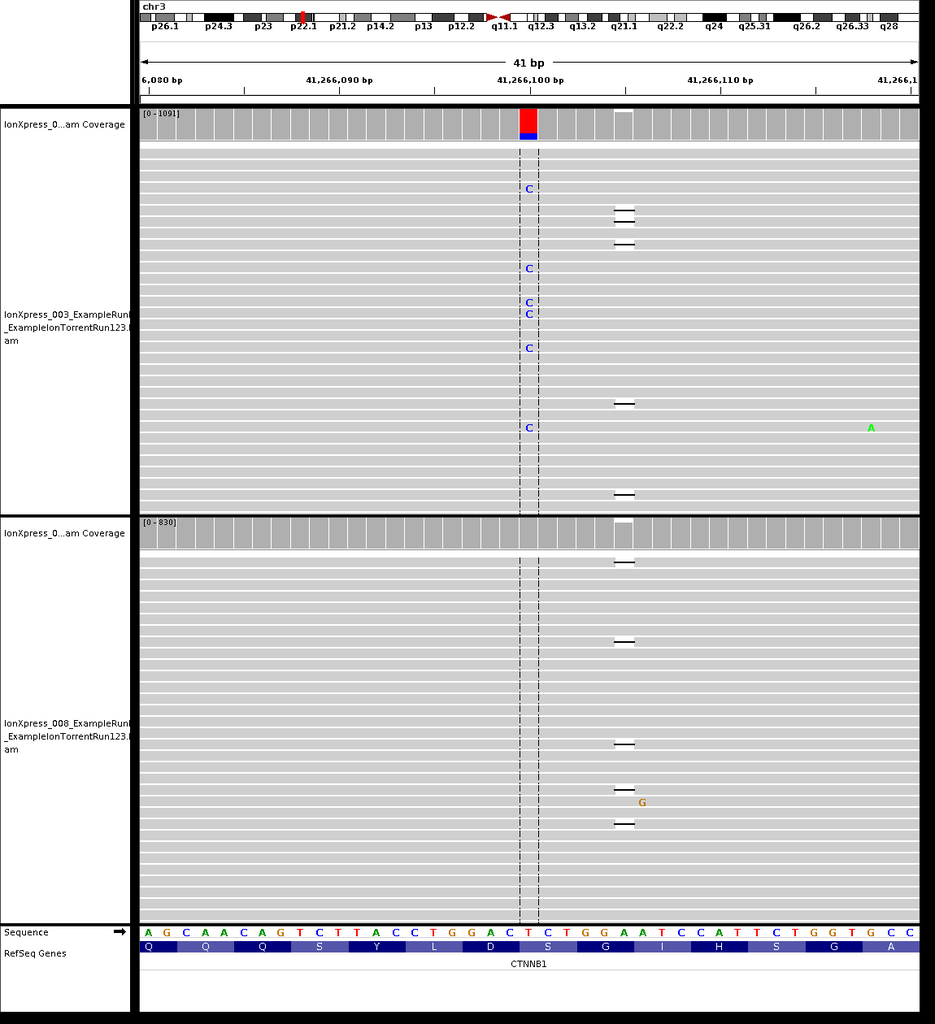

### 3.4.2 Long View

Variant ID:

`ExampleIonTorrentRun123.IonXpress_003.CTNNB1.chr3.41266100.c.T97C`

| Gene | Coding | Amino.Acid.Change | Frequency | Review | Sample.Name | Barcode |
| --- | --- | --- | --- | --- | --- | --- |
| CTNNB1 | c.T97C | p.S33P | 0.214 | US | Sample3 | IonXpress_003 |

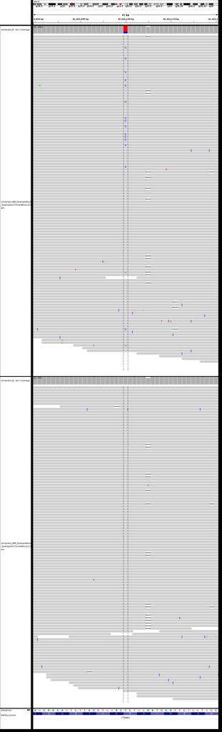

## 3.5 BRAF c.T1799A IonXpress_004

### 3.5.1 Short View

Variant ID:

`ExampleIonTorrentRun123.IonXpress_004.BRAF.chr7.140453136.c.T1799A`

| Gene | Coding | Amino.Acid.Change | Frequency | Review | Sample.Name | Barcode |
| --- | --- | --- | --- | --- | --- | --- |
| BRAF | c.T1799A | p.V600E | 0.168 | KS | Sample4 | IonXpress_004 |

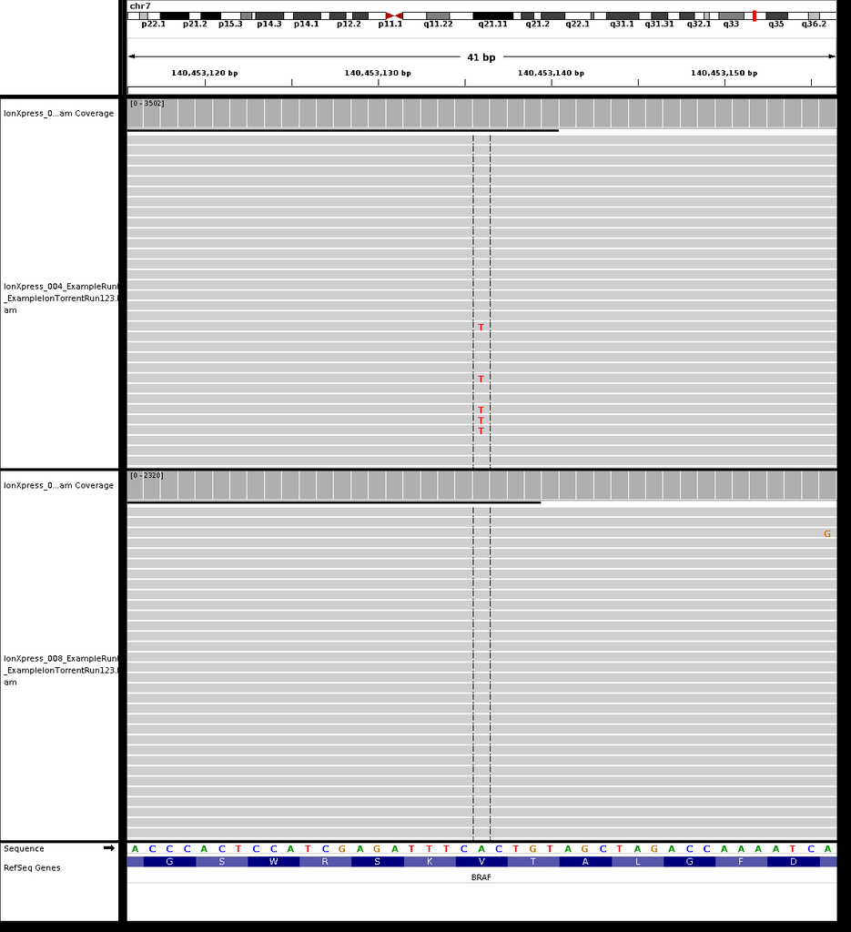

### 3.5.2 Long View

Variant ID:

`ExampleIonTorrentRun123.IonXpress_004.BRAF.chr7.140453136.c.T1799A`

| Gene | Coding | Amino.Acid.Change | Frequency | Review | Sample.Name | Barcode |
| --- | --- | --- | --- | --- | --- | --- |
| BRAF | c.T1799A | p.V600E | 0.168 | KS | Sample4 | IonXpress_004 |

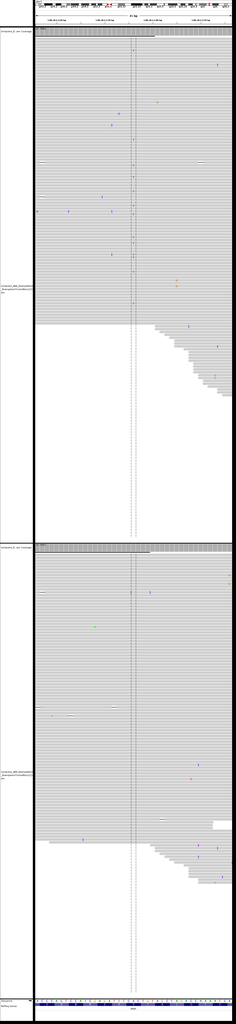

## 3.6 APC c.3932dupT IonXpress_005

### 3.6.1 Short View

Variant ID:

`ExampleIonTorrentRun123.IonXpress_005.APC.chr5.112175222.c.3932dupT`

| Gene | Coding | Amino.Acid.Change | Frequency | Review | Sample.Name | Barcode |
| --- | --- | --- | --- | --- | --- | --- |
| APC | c.3932dupT | p.I1311fs | 0.151 | US | Sample5 | IonXpress_005 |

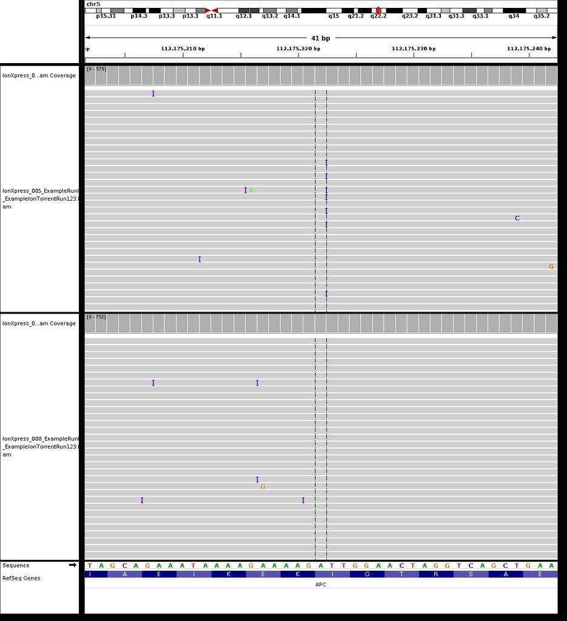

### 3.6.2 Long View

Variant ID:

`ExampleIonTorrentRun123.IonXpress_005.APC.chr5.112175222.c.3932dupT`

| Gene | Coding | Amino.Acid.Change | Frequency | Review | Sample.Name | Barcode |
| --- | --- | --- | --- | --- | --- | --- |
| APC | c.3932dupT | p.I1311fs | 0.151 | US | Sample5 | IonXpress_005 |

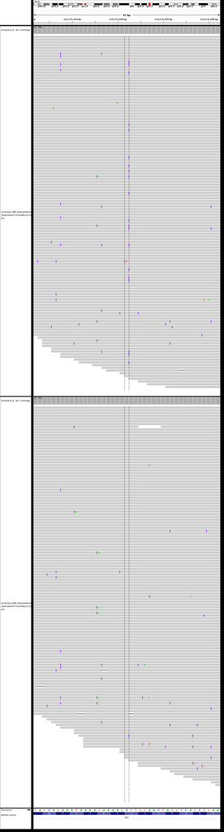

## 3.7 JAK3 c.G2164A IonXpress_005

Variant ID:

`ExampleIonTorrentRun123.IonXpress_005.JAK3.chr19.17945696.c.G2164A`

| Gene | Coding | Amino.Acid.Change | Frequency | Review | Sample.Name | Barcode |
| --- | --- | --- | --- | --- | --- | --- |
| JAK3 | c.G2164A | p.V722I | 0.556 | US | Sample5 | IonXpress_005 |

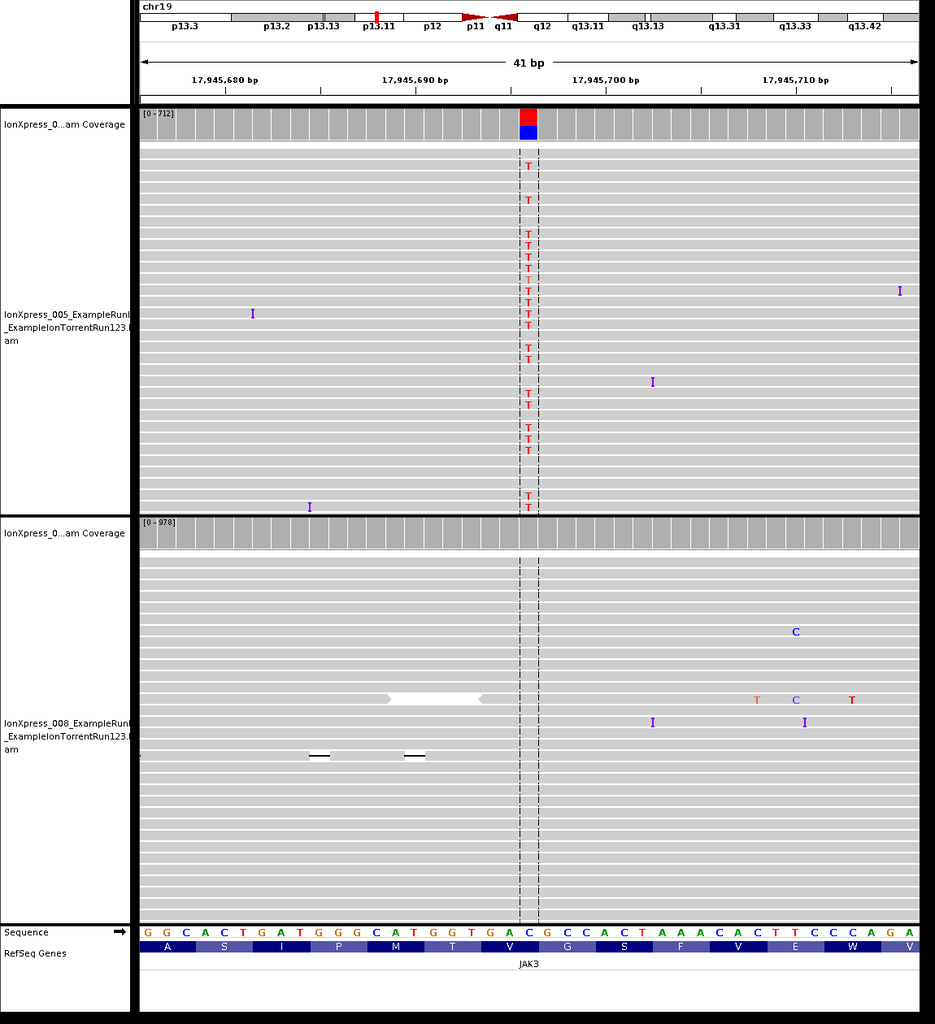

## 3.8 TP53 c.C742T IonXpress_006

Variant ID:

`ExampleIonTorrentRun123.IonXpress_006.TP53.chr17.7577539.c.C742T`

| Gene | Coding | Amino.Acid.Change | Frequency | Review | Sample.Name | Barcode |
| --- | --- | --- | --- | --- | --- | --- |
| TP53 | c.C742T | p.R248W | 0.56 | US | Sample1 | IonXpress_006 |

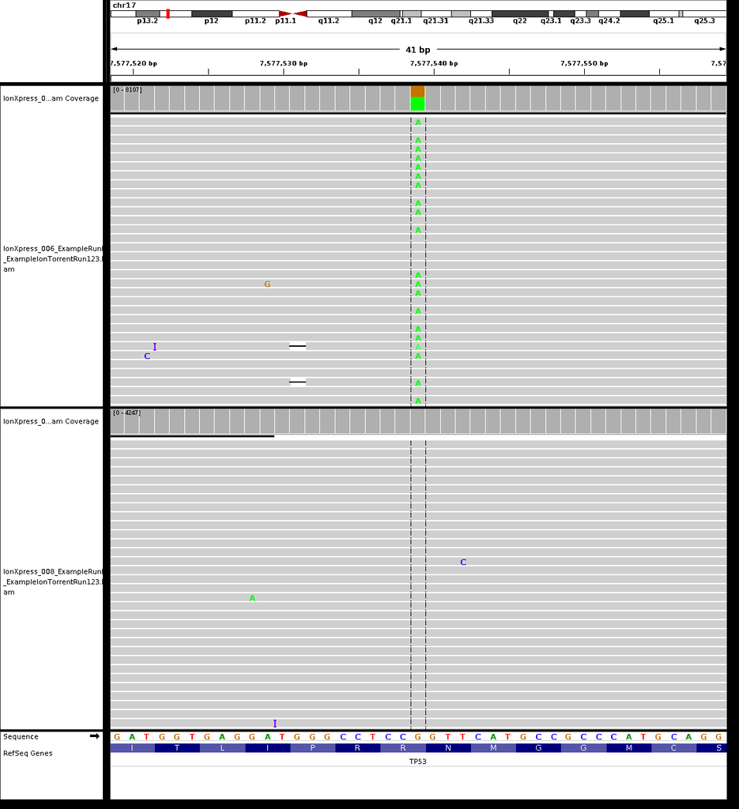

## 3.9 PTEN c.A43T IonXpress_007

Variant ID:

`ExampleIonTorrentRun123.IonXpress_007.PTEN.chr10.89624269.c.A43T`

| Gene | Coding | Amino.Acid.Change | Frequency | Review | Sample.Name | Barcode |
| --- | --- | --- | --- | --- | --- | --- |
| PTEN | c.A43T | p.R15X | 0.34 | US | Sample6 | IonXpress_007 |

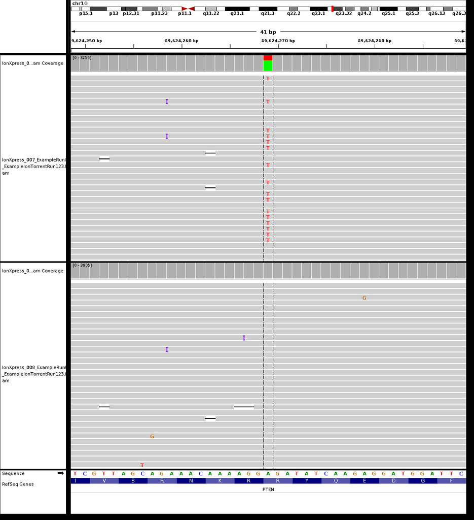

## 3.10 TP53 c.C586T IonXpress_007

Variant ID:

`ExampleIonTorrentRun123.IonXpress_007.TP53.chr17.7578263.c.C586T`

| Gene | Coding | Amino.Acid.Change | Frequency | Review | Sample.Name | Barcode |
| --- | --- | --- | --- | --- | --- | --- |
| TP53 | c.C586T | p.R196X | 0.303 | US | Sample6 | IonXpress_007 |

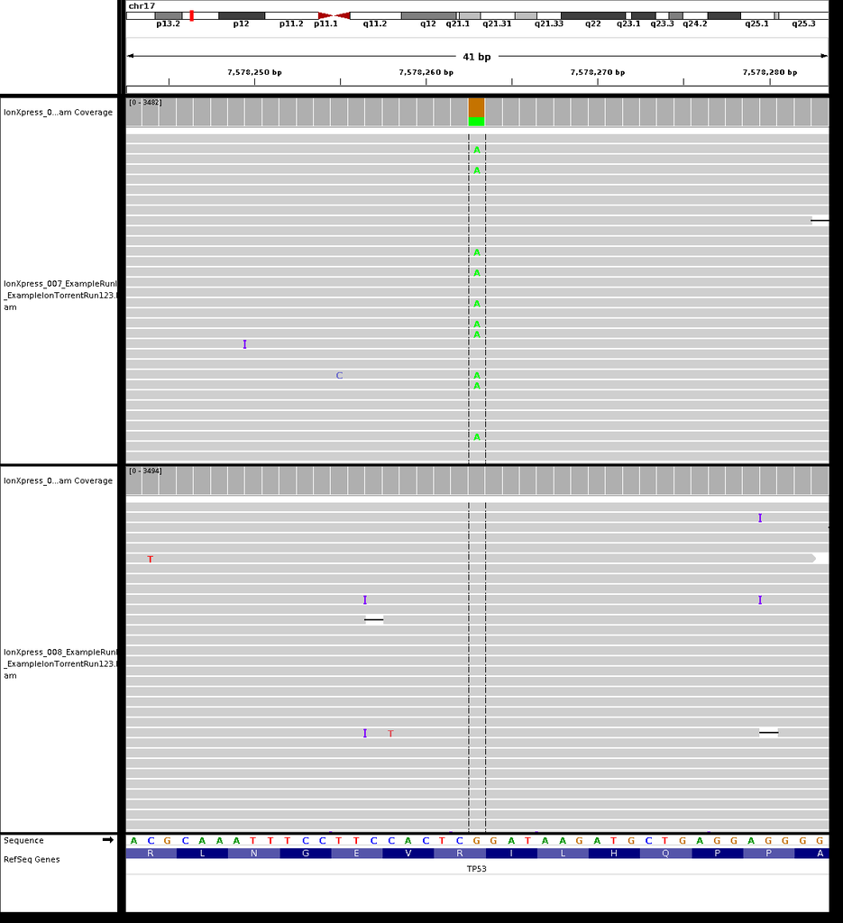

# 4 System Information

## 4.1 Hide

## 4.2 Show

```
## [1] "Linux 2.6.32-573.3.1.el6.x86_64 #1 SMP Thu Aug 13 22:55:16 UTC 2015"
```

```
## [1] "/ifs/home/kellys04/projects/clinical_genomic_reporting/reporter_files/test_output2/ExampleIonTorrentRun123/reports/analysis_overview_report"
```

```
## [1] "Fri Mar 17 14:34:05 EDT 2017"
```